# Examining the relationship between the big-5 personality facets and implicit racial attitudes

Analysis

David Schlegel

10 January, 2024

# Dependencies

```r
library(tidyverse)
library(knitr)
library(kableExtra)
library(janitor)
library(scales)
library(psych)
library(ggplot2)
library(easystats)
library(wesanderson)
library(patchwork)
```

# Data

Load the processed data and apply the global exclusions.

```r
data_processed <- read_csv("../data/processed/data_processed.csv")

#data_processed_after_exclusions <- data_processed |>
#  filter(exclude_participant == "include")
```

# Table with and without exclusions

## Table before exlusions

```r
data_processed |>
  count(name = "n") |>
  kable() |>
  add_header_above(header = c("Whole sample" = 1)) |> # note that you can add header rows to tables like this. The "1" indicates the number of columns the header should span. The sum of these numbers must equal the number of columns or you'll get an error.
  kable_classic(full_width = FALSE)
```

| Whole sample n |
| --- |
| 179 |

# Table after exclusion

```r
data_processed_after_exclusion <- data_processed |>
    filter(exclude_participant == "include")

data_processed_after_exclusion |>
  count(name = "n") |>
  kable() |>
  add_header_above(header = c("Sample after exclusions" = 1)) |>
  kable_classic(full_width = FALSE)
```

| Sample after exclusions n |
| --- |
| 161 |

# Demographics

- Create demographics tables that summarise the mean and SD age, and the frequency and percentage of men vs women in the sample. Report the proportion of participants for which each demographics variable was available.

```r
# Age and SD Age
data_processed_after_exclusion |>
  mutate(age = as.numeric(age)) |>
  summarise(Mean = mean(age, na.rm = TRUE),
            SD = sd(age, na.rm = TRUE)) |>
  mutate_all(.funs = janitor::round_half_up, digits = 1) |>
  kable() |>
  add_header_above(header = c("Age" = 2)) |>
  kable_classic(full_width = FALSE)
```

| Age Mean | Age SD |
| --- | --- |
| 30.6 | 11.3 |

```r
# Frequency and percentage of men vs. women
data_processed_after_exclusion |>
  count(gender) |>
  mutate(percentage_gender = (n / sum(n) * 100),
         percentage_gender = janitor::round_half_up(percentage_gender, digits = 2),
         gender = str_to_title(gender)) |>
  kable(col.names = c("Gender", "Frequency", "Percentage Gender")) |>
  kable_classic(full_width = FALSE)
```

| Gender | Frequency | Percentage Gender |
| --- | --- | --- |
| Female | 86 | 53.42 |
| Male | 53 | 32.92 |
| Not Indicated | 22 | 13.66 |

```r
# Proportion of demographics available
data_processed_after_exclusion |>
  summarise(proportion_age = sum())
```

```
## # A tibble: 1 × 1
##   proportion_age
##            <int>
## 1              0
```

```r
data_processed_after_exclusion |>
  summarise(proportion_with_age_info = sum(age != "not indicated") / n(),
            proportion_with_gender_info = sum(gender != "not indicated") / n()) |>
  mutate(across(everything(), ~janitor::round_half_up(., digits = 2))) |>
  kable(col.names = c("Age", "Gender")) |>
  add_header_above(c("Proportion provided" = 2)) |>
  kable_classic(full_width = FALSE)
```

| Proportion provided Age | Proportion provided Gender |
| --- | --- |
| 0.86 | 0.86 |

# Cronbach’s Alpha

- Calculate Cronbach’s alpha for each of the BFI subscales.

```r
alpha_bfi_agreeableness <- data_processed_after_exclusion |>
  select(starts_with(c("bfi_a"))) |>
  alpha()

alpha_bfi_conscientiousness <- data_processed_after_exclusion |>
  select(starts_with(c("bfi_c"))) |>
  alpha()

alpha_bfi_extraversion <- data_processed_after_exclusion |>
  select(starts_with(c("bfi_e"))) |>
  alpha()

alpha_bfi_openness <- data_processed_after_exclusion |>
  select(starts_with(c("bfi_o"))) |>
  alpha()

alpha_bfi_neuroticism <- data_processed_after_exclusion |>
  select(starts_with(c("bfi_n"))) |>
  alpha()

print(alpha_bfi_agreeableness)
```

```
##
## Reliability analysis
## Call: alpha(x = select(data_processed_after_exclusion, starts_with(c("bfi_a"))))
##
##   raw_alpha std.alpha G6(smc) average_r S/N   ase mean   sd median_r
##       0.78      0.79    0.82       0.3 3.9 0.026  4.4 0.77      0.3
##
##     95% confidence boundaries
##          lower alpha upper
## Feldt     0.73  0.78  0.83
## Duhachek  0.73  0.78  0.83
##
##  Reliability if an item is dropped:
##               raw_alpha std.alpha G6(smc) average_r S/N alpha se var.r med.r
## bfi_a1_recode      0.76      0.77    0.80      0.30 3.4    0.029 0.016  0.30
## bfi_a2             0.76      0.78    0.79      0.30 3.5    0.028 0.016  0.32
## bfi_a3_recode      0.77      0.78    0.80      0.31 3.6    0.028 0.017  0.31
## bfi_a4             0.75      0.77    0.78      0.29 3.3    0.030 0.016  0.29
## bfi_a5             0.77      0.79    0.80      0.32 3.7    0.027 0.013  0.31
## bfi_a6_recode      0.78      0.79    0.81      0.32 3.7    0.026 0.015  0.33
## bfi_a7             0.74      0.75    0.76      0.27 3.0    0.032 0.014  0.26
## bfi_a8_recode      0.77      0.78    0.80      0.31 3.6    0.028 0.018  0.31
## bfi_a9             0.75      0.77    0.78      0.29 3.3    0.029 0.016  0.28
##
##  Item statistics
##                n raw.r std.r r.cor r.drop mean   sd
## bfi_a1_recode 86  0.63  0.62  0.56   0.49  3.4 1.38
## bfi_a2        86  0.56  0.61  0.55   0.46  4.7 0.95
## bfi_a3_recode 86  0.58  0.57  0.49   0.42  4.6 1.37
## bfi_a4        86  0.68  0.67  0.63   0.56  4.7 1.28
## bfi_a5        86  0.54  0.53  0.45   0.37  4.7 1.36
## bfi_a6_recode 86  0.55  0.53  0.44   0.37  4.0 1.52
## bfi_a7        86  0.76  0.77  0.76   0.67  4.8 1.09
## bfi_a8_recode 86  0.59  0.57  0.50   0.44  3.7 1.41
## bfi_a9        86  0.64  0.67  0.63   0.54  4.9 1.02
##
## Non missing response frequency for each item
##                  1    2    3    4    5    6 miss
## bfi_a1_recode 0.07 0.20 0.30 0.16 0.20 0.07 0.47
## bfi_a2        0.00 0.01 0.07 0.34 0.34 0.24 0.47
## bfi_a3_recode 0.03 0.05 0.14 0.19 0.28 0.31 0.47
## bfi_a4        0.02 0.06 0.08 0.22 0.31 0.30 0.47
## bfi_a5        0.03 0.07 0.07 0.17 0.34 0.31 0.47
## bfi_a6_recode 0.05 0.13 0.27 0.13 0.21 0.22 0.47
## bfi_a7        0.01 0.02 0.07 0.21 0.37 0.31 0.47
## bfi_a8_recode 0.06 0.15 0.29 0.19 0.20 0.12 0.47
## bfi_a9        0.00 0.03 0.05 0.20 0.40 0.33 0.47
```

```r
print(alpha_bfi_conscientiousness)
```

```
##
## Reliability analysis
## Call: alpha(x = select(data_processed_after_exclusion, starts_with(c("bfi_c"))))
##
##   raw_alpha std.alpha G6(smc) average_r S/N   ase mean  sd median_r
##       0.81      0.82    0.84      0.34 4.5 0.022  4.4 0.8     0.32
##
##     95% confidence boundaries
##          lower alpha upper
## Feldt     0.76  0.81  0.85
## Duhachek  0.77  0.81  0.85
##
##  Reliability if an item is dropped:
##               raw_alpha std.alpha G6(smc) average_r S/N alpha se var.r med.r
## bfi_c1             0.80      0.81    0.82      0.35 4.2    0.023 0.013  0.32
## bfi_c2_recode      0.78      0.79    0.80      0.32 3.8    0.027 0.017  0.32
## bfi_c3             0.78      0.78    0.79      0.31 3.6    0.025 0.014  0.32
## bfi_c4_recode      0.80      0.81    0.83      0.35 4.3    0.023 0.017  0.36
## bfi_c5_recode      0.79      0.81    0.82      0.34 4.2    0.024 0.017  0.35
## bfi_c6             0.78      0.79    0.81      0.32 3.8    0.025 0.018  0.31
## bfi_c7             0.78      0.79    0.81      0.32 3.8    0.025 0.019  0.32
## bfi_c8             0.80      0.81    0.83      0.35 4.4    0.023 0.018  0.34
## bfi_c9_recode      0.80      0.81    0.82      0.35 4.2    0.024 0.018  0.34
##
##  Item statistics
##                n raw.r std.r r.cor r.drop mean   sd
## bfi_c1        75  0.52  0.59  0.54   0.41  5.1 0.97
## bfi_c2_recode 75  0.75  0.70  0.67   0.63  3.9 1.55
## bfi_c3        75  0.70  0.75  0.74   0.62  5.2 0.95
## bfi_c4_recode 75  0.60  0.56  0.48   0.44  3.5 1.50
## bfi_c5_recode 75  0.66  0.61  0.54   0.51  3.9 1.51
## bfi_c6        75  0.70  0.71  0.67   0.59  4.8 1.23
## bfi_c7        75  0.68  0.70  0.65   0.57  4.7 1.16
## bfi_c8        75  0.50  0.55  0.46   0.40  4.9 0.93
## bfi_c9_recode 75  0.62  0.59  0.52   0.48  3.4 1.40
##
## Non missing response frequency for each item
##                  1    2    3    4    5    6 miss
## bfi_c1        0.00 0.03 0.03 0.20 0.36 0.39 0.53
## bfi_c2_recode 0.07 0.17 0.19 0.13 0.28 0.16 0.53
## bfi_c3        0.00 0.01 0.04 0.16 0.28 0.51 0.53
## bfi_c4_recode 0.05 0.21 0.39 0.08 0.09 0.17 0.53
## bfi_c5_recode 0.05 0.15 0.27 0.15 0.20 0.19 0.53
## bfi_c6        0.01 0.04 0.11 0.19 0.29 0.36 0.53
## bfi_c7        0.01 0.05 0.07 0.20 0.41 0.25 0.53
## bfi_c8        0.00 0.03 0.03 0.24 0.43 0.28 0.53
## bfi_c9_recode 0.11 0.19 0.25 0.19 0.23 0.04 0.53
```

```r
print(alpha_bfi_extraversion)
```

```
##
## Reliability analysis
## Call: alpha(x = select(data_processed_after_exclusion, starts_with(c("bfi_e"))))
##
##   raw_alpha std.alpha G6(smc) average_r S/N   ase mean   sd median_r
##       0.82      0.81    0.83      0.35 4.4 0.021  3.9 0.87     0.37
##
##     95% confidence boundaries
##          lower alpha upper
## Feldt     0.77  0.82  0.86
## Duhachek  0.78  0.82  0.86
##
##  Reliability if an item is dropped:
##               raw_alpha std.alpha G6(smc) average_r S/N alpha se var.r med.r
## bfi_e1             0.77      0.76    0.78      0.32 3.2    0.028 0.024  0.35
## bfi_e2_recode      0.81      0.80    0.81      0.37 4.1    0.023 0.021  0.36
## bfi_e3             0.82      0.81    0.82      0.38 4.4    0.021 0.024  0.38
## bfi_e4             0.81      0.81    0.82      0.38 4.2    0.022 0.025  0.38
## bfi_e5_recode      0.77      0.76    0.78      0.31 3.2    0.028 0.023  0.36
## bfi_e6             0.81      0.80    0.82      0.37 4.1    0.022 0.031  0.38
## bfi_e7_recode      0.81      0.80    0.82      0.37 4.1    0.023 0.024  0.36
## bfi_e8             0.79      0.78    0.80      0.34 3.6    0.025 0.028  0.35
##
##  Item statistics
##                n raw.r std.r r.cor r.drop mean  sd
## bfi_e1        75  0.82  0.81  0.80   0.73  4.2 1.4
## bfi_e2_recode 75  0.62  0.61  0.55   0.48  3.2 1.3
## bfi_e3        75  0.51  0.54  0.45   0.37  4.1 1.2
## bfi_e4        75  0.55  0.57  0.50   0.42  4.5 1.1
## bfi_e5_recode 75  0.82  0.82  0.81   0.74  3.2 1.4
## bfi_e6        75  0.61  0.61  0.52   0.46  4.5 1.4
## bfi_e7_recode 75  0.62  0.60  0.53   0.48  2.9 1.3
## bfi_e8        75  0.73  0.72  0.67   0.61  4.3 1.3
##
## Non missing response frequency for each item
##                  1    2    3    4    5    6 miss
## bfi_e1        0.03 0.12 0.16 0.25 0.20 0.24 0.53
## bfi_e2_recode 0.09 0.17 0.41 0.13 0.12 0.07 0.53
## bfi_e3        0.01 0.08 0.21 0.23 0.37 0.09 0.53
## bfi_e4        0.03 0.03 0.09 0.24 0.48 0.13 0.53
## bfi_e5_recode 0.12 0.17 0.36 0.15 0.15 0.05 0.53
## bfi_e6        0.05 0.05 0.09 0.23 0.33 0.24 0.53
## bfi_e7_recode 0.12 0.32 0.35 0.07 0.08 0.07 0.53
## bfi_e8        0.04 0.04 0.17 0.24 0.31 0.20 0.53
```

```r
print(alpha_bfi_openness)
```

```
##
## Reliability analysis
## Call: alpha(x = select(data_processed_after_exclusion, starts_with(c("bfi_o"))))
##
##   raw_alpha std.alpha G6(smc) average_r S/N   ase mean   sd median_r
##       0.81      0.82    0.86      0.31 4.5 0.022  4.6 0.74     0.31
##
##     95% confidence boundaries
##          lower alpha upper
## Feldt     0.76  0.81  0.85
## Duhachek  0.77  0.81  0.85
##
##  Reliability if an item is dropped:
##               raw_alpha std.alpha G6(smc) average_r S/N alpha se var.r med.r
## bfi_o1             0.77      0.78    0.83      0.29 3.6    0.027 0.023  0.25
## bfi_o2             0.80      0.81    0.86      0.32 4.3    0.024 0.032  0.34
## bfi_o3             0.80      0.80    0.84      0.31 4.1    0.024 0.026  0.31
## bfi_o4             0.79      0.80    0.85      0.31 4.0    0.025 0.031  0.25
## bfi_o5             0.77      0.79    0.83      0.29 3.7    0.027 0.023  0.27
## bfi_o6             0.80      0.81    0.85      0.32 4.2    0.024 0.029  0.31
## bfi_o7_recode      0.81      0.82    0.85      0.33 4.4    0.022 0.026  0.32
## bfi_o8             0.80      0.81    0.84      0.32 4.1    0.024 0.027  0.31
## bfi_o9_recode      0.79      0.80    0.84      0.31 4.1    0.025 0.026  0.29
## bfi_o10            0.80      0.81    0.84      0.33 4.4    0.023 0.022  0.31
##
##  Item statistics
##                n raw.r std.r r.cor r.drop mean   sd
## bfi_o1        86  0.76  0.76  0.76   0.68  4.6 1.12
## bfi_o2        86  0.51  0.55  0.46   0.42  5.5 0.84
## bfi_o3        86  0.59  0.62  0.57   0.47  4.6 1.13
## bfi_o4        86  0.67  0.66  0.60   0.56  4.9 1.17
## bfi_o5        86  0.74  0.75  0.75   0.66  4.5 1.21
## bfi_o6        86  0.58  0.57  0.51   0.46  4.7 1.24
## bfi_o7_recode 86  0.50  0.52  0.44   0.35  4.0 1.37
## bfi_o8        86  0.56  0.60  0.55   0.47  5.0 0.89
## bfi_o9_recode 86  0.66  0.61  0.58   0.52  4.3 1.54
## bfi_o10       86  0.58  0.53  0.49   0.43  3.9 1.46
##
## Non missing response frequency for each item
##                  1    2    3    4    5    6 miss
## bfi_o1        0.01 0.03 0.10 0.28 0.35 0.22 0.47
## bfi_o2        0.01 0.00 0.00 0.10 0.27 0.62 0.47
## bfi_o3        0.02 0.02 0.05 0.36 0.29 0.26 0.47
## bfi_o4        0.02 0.01 0.09 0.13 0.36 0.38 0.47
## bfi_o5        0.03 0.03 0.07 0.30 0.34 0.22 0.47
## bfi_o6        0.02 0.03 0.08 0.26 0.28 0.33 0.47
## bfi_o7_recode 0.02 0.12 0.26 0.21 0.22 0.17 0.47
## bfi_o8        0.00 0.00 0.05 0.24 0.36 0.35 0.47
## bfi_o9_recode 0.07 0.07 0.16 0.16 0.26 0.28 0.47
## bfi_o10       0.09 0.09 0.15 0.22 0.34 0.10 0.47
```

```r
print(alpha_bfi_neuroticism)
```

```
##
## Reliability analysis
## Call: alpha(x = select(data_processed_after_exclusion, starts_with(c("bfi_n"))))
##
##   raw_alpha std.alpha G6(smc) average_r S/N   ase mean   sd median_r
##       0.78      0.78    0.79      0.31 3.5 0.026  3.1 0.81     0.33
##
##     95% confidence boundaries
##          lower alpha upper
## Feldt     0.72  0.78  0.83
## Duhachek  0.73  0.78  0.83
##
##  Reliability if an item is dropped:
##               raw_alpha std.alpha G6(smc) average_r S/N alpha se var.r med.r
## bfi_n1             0.75      0.75    0.76      0.30 3.0    0.030 0.021  0.30
## bfi_n2_recode      0.75      0.75    0.75      0.30 2.9    0.030 0.020  0.30
## bfi_n3             0.76      0.76    0.77      0.32 3.2    0.029 0.017  0.35
## bfi_n4             0.72      0.73    0.73      0.28 2.7    0.033 0.015  0.28
## bfi_n5_recode      0.75      0.75    0.76      0.30 3.1    0.029 0.023  0.31
## bfi_n6             0.80      0.80    0.80      0.36 3.9    0.024 0.014  0.36
## bfi_n7_recode      0.76      0.76    0.76      0.31 3.1    0.029 0.019  0.35
## bfi_n8             0.74      0.74    0.76      0.29 2.9    0.031 0.022  0.31
##
##  Item statistics
##                n raw.r std.r r.cor r.drop mean  sd
## bfi_n1        75  0.66  0.65  0.57   0.51  2.7 1.4
## bfi_n2_recode 75  0.66  0.67  0.62   0.53  2.7 1.2
## bfi_n3        75  0.59  0.59  0.52   0.45  4.0 1.2
## bfi_n4        75  0.77  0.76  0.74   0.64  3.5 1.5
## bfi_n5_recode 75  0.63  0.64  0.57   0.50  2.2 1.1
## bfi_n6        75  0.42  0.41  0.26   0.22  3.8 1.4
## bfi_n7_recode 75  0.60  0.62  0.56   0.46  2.3 1.2
## bfi_n8        75  0.69  0.68  0.62   0.56  3.3 1.3
##
## Non missing response frequency for each item
##                  1    2    3    4    5    6 miss
## bfi_n1        0.21 0.32 0.13 0.24 0.05 0.04 0.53
## bfi_n2_recode 0.15 0.33 0.32 0.11 0.07 0.03 0.53
## bfi_n3        0.04 0.07 0.13 0.40 0.29 0.07 0.53
## bfi_n4        0.11 0.19 0.12 0.32 0.17 0.09 0.53
## bfi_n5_recode 0.29 0.43 0.12 0.13 0.01 0.01 0.53
## bfi_n6        0.07 0.16 0.05 0.44 0.17 0.11 0.53
## bfi_n7_recode 0.27 0.41 0.16 0.09 0.05 0.01 0.53
## bfi_n8        0.11 0.19 0.23 0.29 0.15 0.04 0.53
```

# Descriptives

## BFI

- Create series of histograms of the distribution of scores on each of the BFI subscales and the IAT.

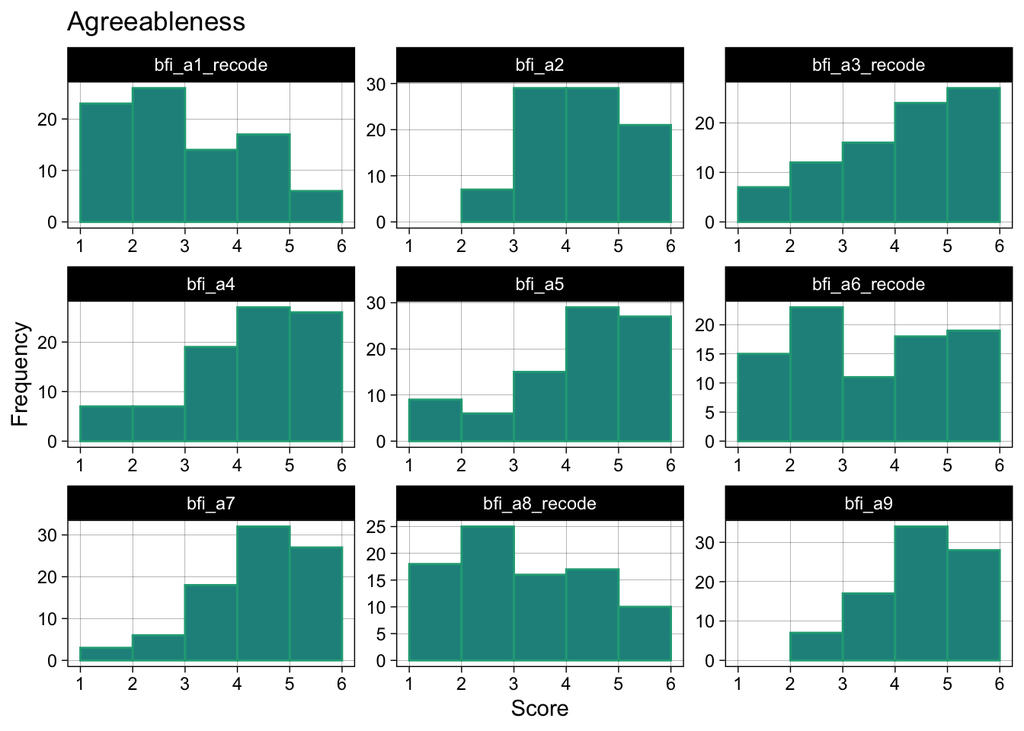

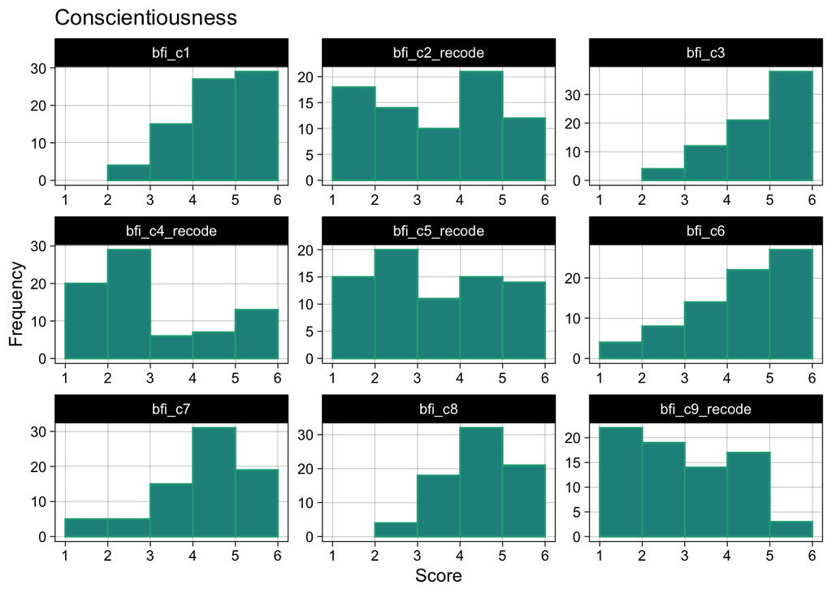

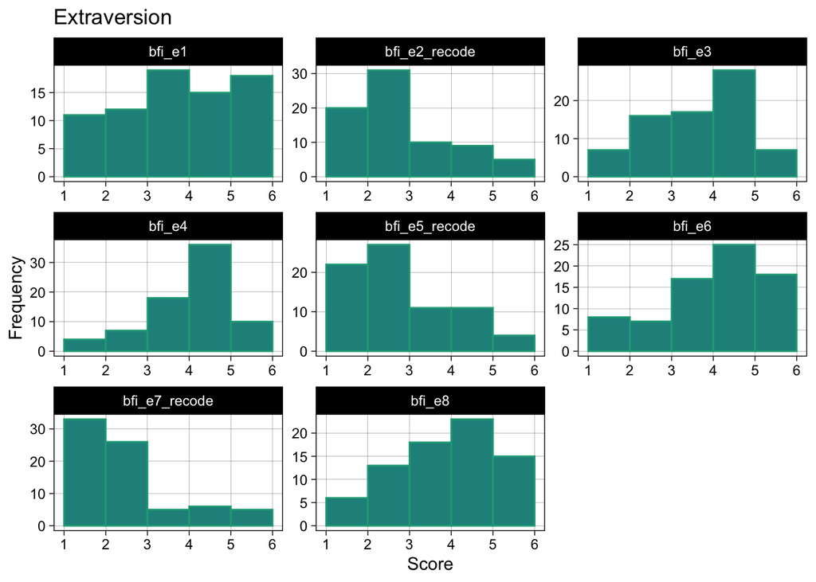

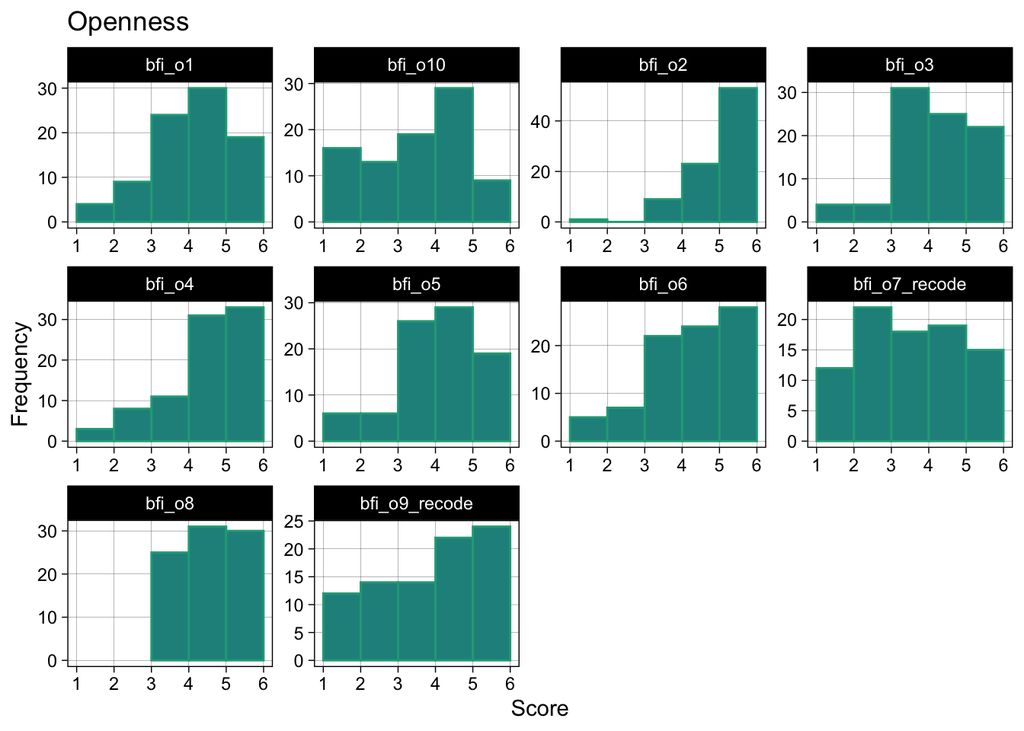

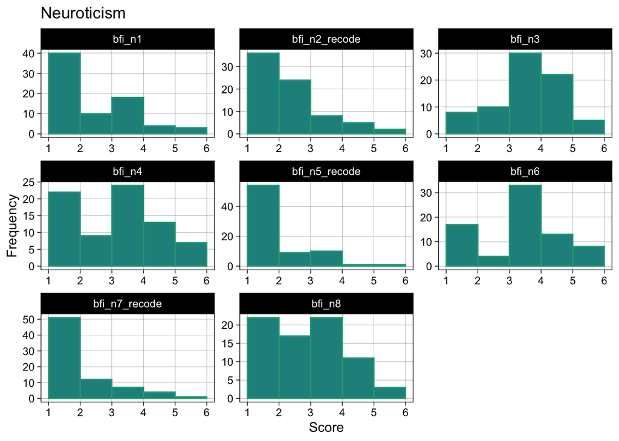

```r
# Transform data
dat_long_bfi <- data_processed_after_exclusion %>%
  select(unique_id, starts_with("bfi")) %>%
  pivot_longer(cols = starts_with("bfi"), names_to = "subscales", values_to = "score") %>%
  drop_na()

# Function to create histograms, so if I need changes I don't have to change it 5 times.
plot_histogram_for_subscale <- function(subscale_prefix, title) {
  data_processed_bfi_histogramm <- dat_long_bfi |>
    filter(str_detect(subscales, subscale_prefix))

  ggplot(data_processed_bfi_histogramm, aes(x = score, fill = subscales)) +
    geom_histogram(binwidth = 1, boundary = 0,
                   fill = viridis_pal(begin = 0.5, option = "viridis")(1),
                   color = viridis_pal(begin = 0.6, option = "viridis")(1)) +
    facet_wrap(~ subscales, scales = "free") +
    xlab("Score") +
    ylab("Frequency") +
    theme_linedraw() +
    scale_x_continuous(breaks = pretty_breaks(n = 7)) +
    coord_cartesian(xlim = c(1, 6)) +
    theme(panel.grid.minor = element_blank()) +
    labs(title = title)
}

# individual titles for histograms
titles <- c("Agreeableness", "Conscientiousness", "Extraversion", "Openness", "Neuroticism")
subscale_prefixes <- c("bfi_a", "bfi_c", "bfi_e", "bfi_o", "bfi_n")

# Plots
plots <- Map(plot_histogram_for_subscale, subscale_prefixes, titles)

print(plots)
```

## IAT

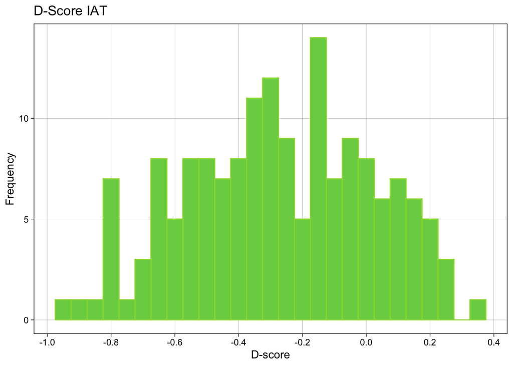

```r
data_processed_after_exclusion |>
  ggplot(aes(x = iat_d_score)) +
  geom_histogram(binwidth = 0.05,
                 fill = viridis_pal(begin = 0.8, option = "viridis")(1),
                 color = viridis_pal(begin = 0.85, option = "viridis")(1)) +
  xlab("D-score") +
  ylab("Frequency") +
  theme_linedraw() +
  scale_x_continuous(breaks = pretty_breaks(n = 7)) +
  theme(panel.grid.minor = element_blank()) +
  labs(title = "D-Score IAT")
```

## Correlation matrix

- Create a table with a correlation matrix of the Pearson’s r correlations between the IAT and the BFI subscales rounded to two decimal places.

```r
cor_matrix <- data_processed_after_exclusion |>
  select(starts_with("mean_bfi"), iat_d_score) |>
  cor(use = "pairwise.complete.obs", method = "pearson") |>
  round(2)

print(cor_matrix)
```

```
##                            mean_bfi_agreeableness mean_bfi_conscientiousness
## mean_bfi_agreeableness                       1.00                         NA
## mean_bfi_conscientiousness                     NA                       1.00
## mean_bfi_extraversion                          NA                       0.09
## mean_bfi_neuroticism                         0.14                         NA
## mean_bfi_openness                              NA                      -0.33
## iat_d_score                                 -0.05                      -0.07
##                            mean_bfi_extraversion mean_bfi_neuroticism
## mean_bfi_agreeableness                        NA                 0.14
## mean_bfi_conscientiousness                  0.09                   NA
## mean_bfi_extraversion                       1.00                   NA
## mean_bfi_neuroticism                          NA                 1.00
## mean_bfi_openness                          -0.10                   NA
## iat_d_score                                 0.10                -0.01
##                            mean_bfi_openness iat_d_score
## mean_bfi_agreeableness                    NA       -0.05
## mean_bfi_conscientiousness             -0.33       -0.07
## mean_bfi_extraversion                  -0.10        0.10
## mean_bfi_neuroticism                      NA       -0.01
## mean_bfi_openness                       1.00        0.07
## iat_d_score                             0.07        1.00
```

# T-Test Women vs. Men

- Run a t-test to test the hypothesis that men and women differ on their scores on the IAT. Report and interpret the results using {report}.

```r
dat_iat_gender <- data_processed_after_exclusion |>
  select(iat_d_score, gender) |>
  filter(gender != "not indicated")

ttest_iat_gender <- t.test(iat_d_score ~ gender, data = dat_iat_gender)

report(ttest_iat_gender)
```

```
## Effect sizes were labelled following Cohen's (1988) recommendations.
##
## The Welch Two Sample t-test testing the difference of iat_d_score by gender
## (mean in group female = -0.25, mean in group male = -0.28) suggests that the
## effect is positive, statistically not significant, and very small (difference =
## 0.04, 95% CI [-0.06, 0.14], t(111.55) = 0.77, p = 0.442; Cohen's d = 0.15, 95%
## CI [-0.23, 0.52])
```

# Regressions

- Run a series of regressions to test the hypotheses that each BFI subscale predicts IAT scores. Run separate regressions for each subscale rather than a multiple regression. Report and interpret the results using {report}.

```r
regression_iat_bfi_agreeableness <- lm(iat_d_score ~ mean_bfi_agreeableness, data = data_processed_after_exclusion)

regression_iat_bfi_conscientiousness <- lm(iat_d_score ~ mean_bfi_conscientiousness, data = data_processed_after_exclusion)

regression_iat_bfi_extraversion <- lm(iat_d_score ~ mean_bfi_extraversion, data = data_processed_after_exclusion)

regression_iat_bfi_openness <- lm(iat_d_score ~ mean_bfi_openness, data = data_processed_after_exclusion)

regression_iat_bfi_neuroticism <- lm(iat_d_score ~ mean_bfi_neuroticism, data = data_processed_after_exclusion)

report(regression_iat_bfi_agreeableness)
```

```
## We fitted a linear model (estimated using OLS) to predict iat_d_score with
## mean_bfi_agreeableness (formula: iat_d_score ~ mean_bfi_agreeableness). The
## model explains a statistically not significant and very weak proportion of
## variance (R2 = 2.63e-03, F(1, 84) = 0.22, p = 0.639, adj. R2 = -9.25e-03). The
## model's intercept, corresponding to mean_bfi_agreeableness = 0, is at -0.18
## (95% CI [-0.55, 0.19], t(84) = -0.96, p = 0.340). Within this model:
##
##   - The effect of mean bfi agreeableness is statistically non-significant and
## negative (beta = -0.02, 95% CI [-0.10, 0.06], t(84) = -0.47, p = 0.639; Std.
## beta = -0.05, 95% CI [-0.27, 0.17])
##
## Standardized parameters were obtained by fitting the model on a standardized
## version of the dataset. 95% Confidence Intervals (CIs) and p-values were
## computed using a Wald t-distribution approximation.
```

```r
report(regression_iat_bfi_conscientiousness)
```

```
## We fitted a linear model (estimated using OLS) to predict iat_d_score with
## mean_bfi_conscientiousness (formula: iat_d_score ~ mean_bfi_conscientiousness).
## The model explains a statistically not significant and very weak proportion of
## variance (R2 = 4.53e-03, F(1, 73) = 0.33, p = 0.566, adj. R2 = -9.11e-03). The
## model's intercept, corresponding to mean_bfi_conscientiousness = 0, is at -0.18
## (95% CI [-0.54, 0.19], t(73) = -0.96, p = 0.338). Within this model:
##
##   - The effect of mean bfi conscientiousness is statistically non-significant and
## negative (beta = -0.02, 95% CI [-0.11, 0.06], t(73) = -0.58, p = 0.566; Std.
## beta = -0.07, 95% CI [-0.30, 0.17])
##
## Standardized parameters were obtained by fitting the model on a standardized
## version of the dataset. 95% Confidence Intervals (CIs) and p-values were
## computed using a Wald t-distribution approximation.
```

```r
report(regression_iat_bfi_extraversion)
```

```
## We fitted a linear model (estimated using OLS) to predict iat_d_score with
## mean_bfi_extraversion (formula: iat_d_score ~ mean_bfi_extraversion). The model
## explains a statistically not significant and very weak proportion of variance
## (R2 = 0.01, F(1, 73) = 0.77, p = 0.383, adj. R2 = -3.11e-03). The model's
## intercept, corresponding to mean_bfi_extraversion = 0, is at -0.41 (95% CI
## [-0.71, -0.11], t(73) = -2.71, p = 0.008). Within this model:
##
##   - The effect of mean bfi extraversion is statistically non-significant and
## positive (beta = 0.03, 95% CI [-0.04, 0.11], t(73) = 0.88, p = 0.383; Std. beta
## = 0.10, 95% CI [-0.13, 0.33])
##
## Standardized parameters were obtained by fitting the model on a standardized
## version of the dataset. 95% Confidence Intervals (CIs) and p-values were
## computed using a Wald t-distribution approximation.
```

```r
report(regression_iat_bfi_openness)
```

```
## We fitted a linear model (estimated using OLS) to predict iat_d_score with
## mean_bfi_openness (formula: iat_d_score ~ mean_bfi_openness). The model
## explains a statistically not significant and very weak proportion of variance
## (R2 = 5.08e-03, F(1, 73) = 0.37, p = 0.544, adj. R2 = -8.55e-03). The model's
## intercept, corresponding to mean_bfi_openness = 0, is at -0.36 (95% CI [-0.62,
## -0.10], t(73) = -2.74, p = 0.008). Within this model:
##
##   - The effect of mean bfi openness is statistically non-significant and positive
## (beta = 0.03, 95% CI [-0.06, 0.11], t(73) = 0.61, p = 0.544; Std. beta = 0.07,
## 95% CI [-0.16, 0.30])
##
## Standardized parameters were obtained by fitting the model on a standardized
## version of the dataset. 95% Confidence Intervals (CIs) and p-values were
## computed using a Wald t-distribution approximation.
```

```r
report(regression_iat_bfi_neuroticism)
```

```
## We fitted a linear model (estimated using OLS) to predict iat_d_score with
## mean_bfi_neuroticism (formula: iat_d_score ~ mean_bfi_neuroticism). The model
## explains a statistically not significant and very weak proportion of variance
## (R2 = 1.16e-04, F(1, 84) = 9.77e-03, p = 0.921, adj. R2 = -0.01). The model's
## intercept, corresponding to mean_bfi_neuroticism = 0, is at -0.25 (95% CI
## [-0.65, 0.16], t(84) = -1.20, p = 0.234). Within this model:
##
##   - The effect of mean bfi neuroticism is statistically non-significant and
## negative (beta = -4.35e-03, 95% CI [-0.09, 0.08], t(84) = -0.10, p = 0.921;
## Std. beta = -0.01, 95% CI [-0.23, 0.21])
##
## Standardized parameters were obtained by fitting the model on a standardized
## version of the dataset. 95% Confidence Intervals (CIs) and p-values were
## computed using a Wald t-distribution approximation.
```

# Scatter Plots

- Create series of scatter plots of how BFI subscale scores predict IAT scores. Add regression lines. These plots therefore illustrate the same results as the regressions above. Make the plots presentable and publication quality- you may decide the details of this with one exception: Extreme scores on the IAT (defined as participants whose scores in the top and bottom 10% of IAT scores) should use a triangular shape rather than a dot. A single combined plot should be created, containing 5 component plots, with the personality facet being examined in each clearly labelled. This plot should be printed in the html file but also saved to disk as both png/pdf.

```r
data_processed_after_exclusion <- data_processed_after_exclusion |>
  mutate(extreme_scores_iat = ifelse(iat_d_score > quantile(iat_d_score, 0.9) | iat_d_score < quantile(iat_d_score, 0.1), "Extreme", "Not extreme"))

# to longer
dat_scatterplots <- data_processed_after_exclusion |>
  select(unique_id, starts_with(c("mean_bfi")), iat_d_score, extreme_scores_iat) |>
  pivot_longer(cols = starts_with("mean_bfi"), names_to = "subscales", values_to = "score")

# Load colors
wes_palette <- wes_palette("Zissou1", n = 5, type = "continuous")

# Function to create the scatterplot
create_scatterplot <- function(data, subscale, title) {
  data |>
    filter(subscales == subscale) |>
    ggplot(aes(x = score, y = iat_d_score)) +
      geom_point(aes(color = extreme_scores_iat, shape = extreme_scores_iat)) +
      geom_smooth(method = "lm", se = FALSE, aes(group = 1), color = wes_palette[3]) +
      scale_color_manual(values = c("Extreme" = wes_palette[2], "Not extreme" = wes_palette[1]),
                         name = "IAT-Score classification",
                         labels = c("Top/bottom 10% quantil", "10%-90% quantil")) +
    theme_light() +
    labs(x = "BFI Score", y = "IAT Score",
         title = title,
         color = "IAT Score Category", shape = "IAT Score Category") +
    theme(axis.text = element_text(size = 10),
      axis.title = element_text(size = 8),
      plot.title = element_text(size = 10)) +
    scale_shape_manual(values = c("Extreme" = 17, "Not extreme" = 16),
                       name = "IAT-Score classification",
                       labels = c("Top/bottom 10% quantil", "10%-90% quantil"))
}

# Agreeableness Plot
p1_a <- create_scatterplot(dat_scatterplots, "mean_bfi_agreeableness", "Agreeableness")

# Conscientiousness Plot
p2_c <- create_scatterplot(dat_scatterplots, "mean_bfi_conscientiousness", "Conscientiousness")

# Extraversion Plot
p3_e <- create_scatterplot(dat_scatterplots, "mean_bfi_extraversion", "Extraversion")

# Extraversion Plot
p4_o <- create_scatterplot(dat_scatterplots, "mean_bfi_openness", "Openness")

# Extraversion Plot
p5_n <- create_scatterplot(dat_scatterplots, "mean_bfi_neuroticism", "Neuroticism")
```

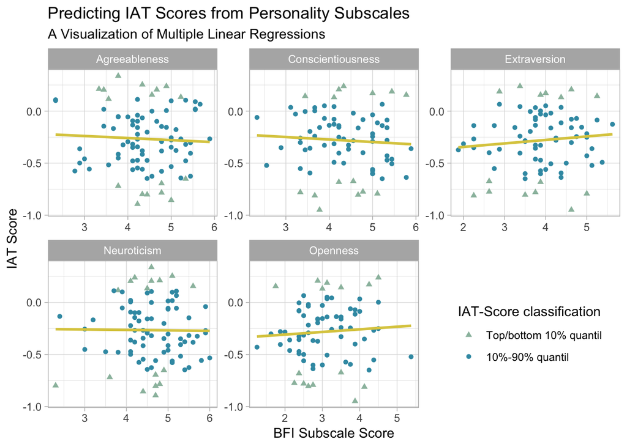

```r
# Faccetted Plots
my_labeller <- as_labeller(c(
  mean_bfi_agreeableness = "Agreeableness",
  mean_bfi_conscientiousness = "Conscientiousness",
  mean_bfi_extraversion = "Extraversion",
  mean_bfi_openness = "Openness",
  mean_bfi_neuroticism = "Neuroticism"
))



ggplot(dat_scatterplots, aes(x = score, y = iat_d_score)) +
  geom_point(aes(color = extreme_scores_iat, shape = extreme_scores_iat)) +
  geom_smooth(method = "lm", se = FALSE, aes(group = 1), color = wes_palette[3]) +
  scale_color_manual(
    values = c("Extreme" = wes_palette[2], "Not extreme" = wes_palette[1]),
    name = "IAT-Score classification",
    labels = c("Top/bottom 10% quantil", "10%-90% quantil")) +
  facet_wrap(~subscales, scales = "free", labeller = my_labeller) +
  theme_light() +
  labs(x = "BFI Subscale Score", y = "IAT Score",
       title = "Predicting IAT Scores from Personality Subscales",
       subtitle = "A Visualization of Multiple Linear Regressions",
       color = "IAT Score Category", shape = "IAT Score Category") +
  scale_shape_manual(
    values = c("Extreme" = 17, "Not extreme" = 16),
    name = "IAT-Score classification",
    labels = c("Top/bottom 10% quantil", "10%-90% quantil")) +
  theme(legend.position = c(0.98, 0.1),
        legend.justification = c("right", "bottom"))
```

```r
ggsave("../communication/scatterplot_bfi_iat.png")
ggsave("../communication/scatterplot_bfi_iat.pdf",  device = cairo_pdf, width = 10, height = 8)
```

## Combine plots

- Combine these scatter plots into one ggplot object using {patchwork} and print the combined plot in your .Rmd and .html. Save the combined plot to disk as a .pdf and .png in the “communications” folder.

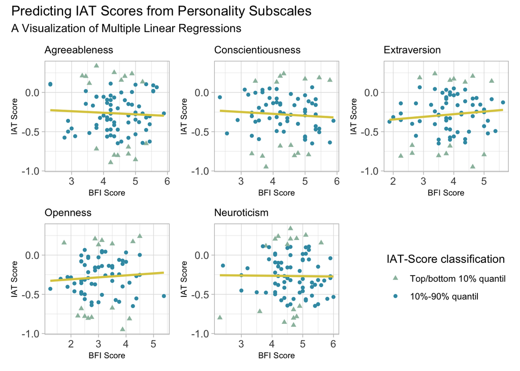

```r
combined_plot <- p1_a + p2_c + p3_e + p4_o + p5_n + guide_area() + plot_layout(guides = 'collect')

combined_plot <- combined_plot + plot_annotation(
  title = "Predicting IAT Scores from Personality Subscales",
  subtitle = "A Visualization of Multiple Linear Regressions")

print(combined_plot)
```

```r
ggsave("../communication/combined_plot.png")
ggsave("../communication/combined_plot.pdf", device = cairo_pdf, width = 10, height = 8)
```